# Assignment #1 - Linear Regression

# Introduction

**Aim: This assignment work aims to how Linear regression works on data and how predictions can be made effieciently using Least square and Least Mean square method.**

**Implementation of two methods is done in this assignment 1. Least squares method 2. Least mean squares method.**

**We will train our model using these two methods and then see how those models works while doing prediction.**

**Also in order to get stable data we will see how preprocessing and cleaning of data is done.**

# Data

*This dataset includes a hourly/daily summary for Szeged, Hungary area, between 2006 and 2016.*

*Data available in the hourly response:*

```
.Formatted Date
.summary
.precipType
.temperature
.apparent Temperature
.humidity
.windSpeed
.windBearing
.visibility
.loudCover
.pressure
```

## Description

Apparent Temperature is the temperature equivalent perceived by humans, casued by the combined effects of air temperature, humdity, wind speed and windbearing. Relationship between different variables with apparent temperature using regression model. Also we can see some features are least significant and some are more significant.

Source : https://www.kaggle.com/budincsevity/szeged-weather

## Importing libraries

```python
import numpy as np
import pandas as pd
import matplotlib.pyplot as plt
%matplotlib inline
import seaborn as sns
sns.set(style="darkgrid")
```

## Reading of the Data

```python
df_reg = pd.read_csv(r'weatherHistory.csv')
```

## Plots for understanding data

### 1. Correlation Diagram between different features

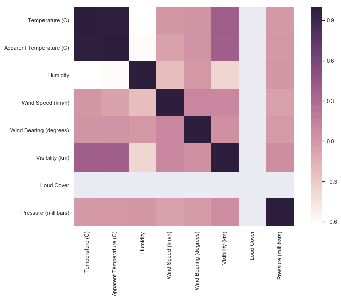

```python
corr = df_reg.corr()
plt.figure(figsize=(12,8))
cmap = sns.cubehelix_palette(light=1, as_cmap=True)
sns.heatmap(corr,cmap=cmap, square=True)
```

**Observations:**

- Figure is symmetric along the diagonal.
- Correlation matrix is plotted using correlation coeficient.
- Relation between Humidity and Temperature or Apparent Temperature shows negative relation.
- Temperature and apparent temperature are strongly co-related.

### 2. Average Temperature variation in 2006 per month

```python
df_temp = df_reg.copy()
df_temp["Formatted Date"]= (df_temp["Formatted Date"].str.rsplit("-", n = 1, expand = True))
df_temp["Formatted Date"].head()
```

```
0    2006-04
1    2006-04
2    2006-04
3    2006-04
4    2006-04
Name: Formatted Date, dtype: object
```

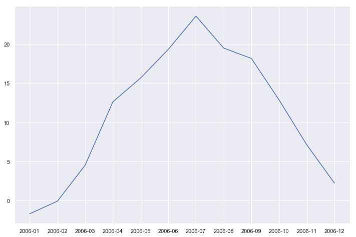

```python
plt.figure(figsize=(12,8))
df_temp = df_temp.sort_values(['Formatted Date'])

df_temp = (df_temp.head(8760))
df_temp= df_temp.sort_values(['Formatted Date'])
df_temp = (df_temp.groupby('Formatted Date', as_index=False)['Temperature (C)'].mean())
plt.plot(df_temp["Formatted Date"], df_temp["Temperature (C)"])
```

**Observations:**

### 3. Summary Count plot

```python
df_reg.describe()
```

|  | Temperature (C) | Apparent Temperature (C) | Humidity | Wind Speed (km/h) | Wind Bearing (degrees) | Visibility (km) | Loud Cover | Pressure (millibars) |
| --- | --- | --- | --- | --- | --- | --- | --- | --- |
| count | 96453.000000 | 96453.000000 | 96453.000000 | 96453.000000 | 96453.000000 | 96453.000000 | 96453.0 | 96453.000000 |
| mean | 11.932678 | 10.855029 | 0.734899 | 10.810640 | 187.509232 | 10.347325 | 0.0 | 1003.235956 |
| std | 9.551546 | 10.696847 | 0.195473 | 6.913571 | 107.383428 | 4.192123 | 0.0 | 116.969906 |
| min | -21.822222 | -27.716667 | 0.000000 | 0.000000 | 0.000000 | 0.000000 | 0.0 | 0.000000 |
| 25% | 4.688889 | 2.311111 | 0.600000 | 5.828200 | 116.000000 | 8.339800 | 0.0 | 1011.900000 |
| 50% | 12.000000 | 12.000000 | 0.780000 | 9.965900 | 180.000000 | 10.046400 | 0.0 | 1016.450000 |
| 75% | 18.838889 | 18.838889 | 0.890000 | 14.135800 | 290.000000 | 14.812000 | 0.0 | 1021.090000 |
| max | 39.905556 | 39.344444 | 1.000000 | 63.852600 | 359.000000 | 16.100000 | 0.0 | 1046.380000 |

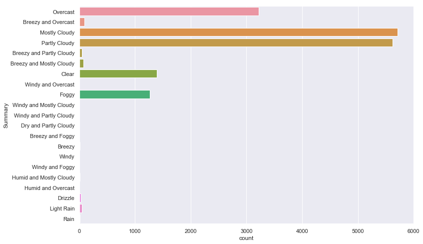

```python
df_month= df_reg[(df_reg['Formatted Date'] > '2015')]
plt.figure(figsize=(12,8))
sns.countplot(y=df_month['Summary'])
```

**Observations:**

```python
df_precip = df_month.dropna(subset=['Precip Type'])
df_precip.isnull().sum()
```

```
Formatted Date              0
Summary                     0
Precip Type                 0
Temperature (C)             0
Apparent Temperature (C)    0
Humidity                    0
Wind Speed (km/h)           0
Wind Bearing (degrees)      0
Visibility (km)             0
Loud Cover                  0
Pressure (millibars)        0
Daily Summary               0
dtype: int64
```

### 4. Temperature and Humidity comparison over a day in 2006

```python
df1 = pd.read_csv(r'weatherHistory.csv',encoding ='latin-1')
df1["Formatted Date"]=df1["Formatted Date"].str.split("+", n = 1, expand = True)
df1["Formatted Date"]=df1["Formatted Date"].str.split(":", n = 1, expand = True)
df1= df1[(df1['Formatted Date'] < '2006-01-02')]
df1["Formatted Date"]=(df1["Formatted Date"].str.split(" ", n = 1, expand = True))[1]
df1= df1.sort_values(['Formatted Date'])
```

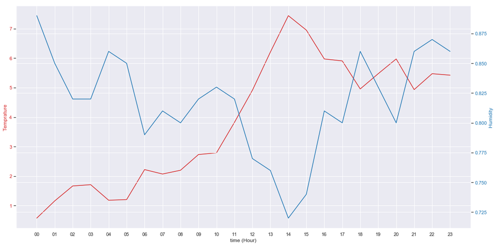

```python
t = df1['Formatted Date']
data1 = df1['Temperature (C)']
data2 = df1['Humidity']

fig, ax1 = plt.subplots(figsize=(16,8))

color = 'tab:red'
ax1.set_xlabel('time (Hour)')
ax1.set_ylabel('Temprature', color=color)
ax1.plot(t, data1, color=color)

ax1.tick_params(axis='y', labelcolor=color)

ax2 = ax1.twinx()  # instantiate a second axes that shares the same x-axis

color = 'tab:blue'
ax2.set_ylabel('Humidity', color=color)  # we already handled the x-label with ax1
ax2.plot(t, data2, color=color)
ax2.tick_params(axis='y', labelcolor=color)
fig.tight_layout()  # otherwise the right y-label is slightly clipped
plt.show()
```

**Observations:**

- As Humidity decreases, temperature increases in a day per hour which tells us that humidity could be the key feature while predicting Apparent temprature.

### 5. Temperature Distribution

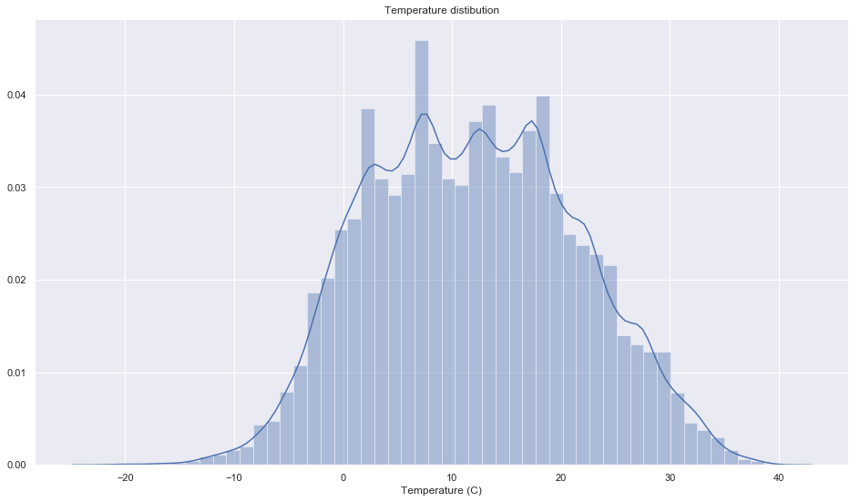

```python
plt.figure(figsize = (16, 9))
plt.title('Temperature distibution')
sns.distplot(df_reg['Temperature (C)'])
plt.show()
```

**Observations:**

- Standard deviation between 0 and 20 is more in temperature feature.

## Preliminary observation

[output not shown]

## Preprocessing of the data

Correlation matrix drawn above shows that variable 'Loud cover' has no correlation with any of the variable. Hence dropping that variable.

```python
df_reg= df_reg.drop(columns=['Loud Cover'])
```

**To check the variable information like type of the variables, NULL or NOT-NULL.**

```python
df_reg.info()
```

```
<class 'pandas.core.frame.DataFrame'>
RangeIndex: 96453 entries, 0 to 96452
Data columns (total 11 columns):
Formatted Date              96453 non-null object
Summary                     96453 non-null object
Precip Type                 95936 non-null object
Temperature (C)             96453 non-null float64
Apparent Temperature (C)    96453 non-null float64
Humidity                    96453 non-null float64
Wind Speed (km/h)           96453 non-null float64
Wind Bearing (degrees)      96453 non-null float64
Visibility (km)             96453 non-null float64
Pressure (millibars)        96453 non-null float64
Daily Summary               96453 non-null object
dtypes: float64(7), object(4)
memory usage: 8.1+ MB
```

### Box plot to check outliers in the data

```
6
Temperature (C)
Apparent Temperature (C)
Humidity
Wind Speed (km/h)
Wind Bearing (degrees)
Visibility (km)
```

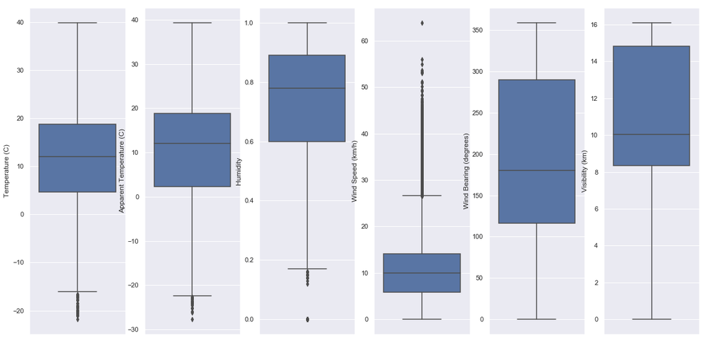

```python
df_num= df_reg[['Temperature (C)','Apparent Temperature (C)','Humidity','Wind Speed (km/h)','Wind Bearing (degrees)','Visibility (km)']]
count =0
#fig, axes =plt.subplots(1,2)
print(df_num.shape[1])
fig, axes =plt.subplots(1,6,figsize=(20,10))
for i in range (0,df_num.shape[1]):
    print(df_num.columns.values[i])
    sns.boxplot(y=str(df_num.columns.values[i]),data=df_num,ax=axes[i%6])
```

# Method

### Review of the linear models

### Least Squares

We use Least Squares method because we are looking for a probabilistic model that fits the observed data best and can be used for future prediction. The least squares model does much better in fitting a curve than many methods such as plotting the average slope of all the slopes between the pait of points ( x E X , t E T )

We can solve this by, setting derivative with respect to w to zero. After solving this we will get the normal function

$$ \begin{align} w &= \big(X^\top X\big)^{-1} X^\top t \end{align} $$

Where X is our independent variables data and T is target variable.

**Implementation:**

A LinearRegress class is defined with initialization of base class as LinearModel where weight 'w' is initizlized as None. Class LinearModel has two function which we will use later in the code.

```
1.check_matrix : This function check the dimension of the matrix. If dimensions are not equal to 2 it throws exception.
2.add_ones : This function is used to create column in X input by adding 1, so that matrix operations can be performed correctly.
```

LinearRegress class has 2 important functions:

```
1.train() : This function accepts 2 arguments , first is X, input array (independent variable data) and second is T (target label) data. We have implemented equation of the normal function in train function which calculates the value of w.
2.use() : This function is used to prdict the new values using w calculated in train function using testing data's features.
```

### Least Mean squares

In Least Squares, we are using the whole dataset to calculate the value of w, this can be very costly if the dataset is large. When data is sufficiently large, we can consider sequential or online learning using Least Mean Squares method. During the online learning process, we introduce a data point one by one, and update the parameters. Using the updated parameters, it makes a new estimation and repeat these steps.

For this, we start with an initial guess $w$ and changes it as it reads more data until it converges. When $k$ represents the steps for the repetition,

$$ w^{(k+1)} = w^{(k)} - \alpha \nabla E_k $$

where $E_k$ is the error for the $k$'th sample and $\alpha$ is a learning rate. This is called *stochastic gradient descent* or *sequential gradient descent*.

Solving this gives us:

$$ w^{(k+1)} = w^{(k)} - \alpha \Big( {w^{(k)}}^\top x_k - t_k \Big) x_k. $$

**Implementation**

In LMS also same super and base class are used as in LS. One additional class as LMS is created which has following functions:

```
1.train(): train function calls train_step function for each sample.
2.train_step(): train_step function adds ones to x and then initializes w(once) and start calculating value of w till it converges.
3.use(): use function will give the dot product of X and w which is nothing but the predicted value.
```

Also in LMS class, when we are creating a model, we need to pass the alpha value, i.e the learning rate.

### Super Classs Definition

```python
from abc import ABC, abstractmethod

# Super class for machine learning models

class BaseModel(ABC):
    """ Super class for ITCS Machine Learning Class"""

    @abstractmethod
    def train(self, X, T):
        pass

    @abstractmethod
    def use(self, X):
        pass


class LinearModel(BaseModel):

    """
        Abstract class for a linear model

        Attributes
        ==========
        w       ndarray
                weight vector/matrix
    """

    def __init__(self):
        """
            weight vector w is initialized as None
        """
        self.w = None

    def _check_matrix(self, mat, name):
        if len(mat.shape) != 2:
            raise ValueError(''.join(["Wrong matrix ", name]))

    # add a basis
    def add_ones(self, X):
        """
            add a column basis to X input matrix
        """
        self._check_matrix(X, 'X')
        return np.hstack((np.ones((X.shape[0], 1)), X))

    ####################################################
    #### abstract funcitons ############################
    @abstractmethod
    def train(self, X, T):
        """
            train linear model

            parameters
            -----------
            X     2d array
                  input data
            T     2d array
                  target labels
        """
        pass

    @abstractmethod
    def use(self, X):
        """
            apply the learned model to input X

            parameters
            ----------
            X     2d array
                  input data

        """
        pass
```

### Least Squares

```python
# Linear Regression Class for least squares
class LinearRegress(LinearModel):

    """
        LinearRegress class

        attributes
        ===========
        w    nd.array
             weights
    """
    def __init__(self):
        LinearModel.__init__(self)

    # train lease-squares model
    def train(self, X, T):
        X = self.add_ones(X)
        self.w = np.linalg.lstsq(X.T @ X, X.T @ T)[0]
        return self.w

    # apply the learned model to data X
    def use(self, X):
        X = self.add_ones(X)
        return X @ self.w
```

### Least Mean Squares

```python
import collections # for checking iterable instance

# LMS class
class LMS(LinearModel):
    """
        Lease Mean Squares. online learning algorithm

        attributes
        ==========
        w        nd.array
                 weight matrix
        alpha    float
                 learning rate
    """
    def __init__(self, alpha):
        LinearModel.__init__(self)
        self.alpha = alpha

    # batch training by using train_step function
    def train(self, X, T):
        # Iterate over all values of X and T
        for x, t in zip(X, T):
            # Call to train_Step function
            self.train_step(x, t)
        return self.w

    # train LMS model one step
    # here the x is 1d vector
    def train_step(self, x, t):
        x = np.insert(x, 0, 1).reshape(-1, 1)
        # Initialize weight w in first run
        if self.w is None:
            self.w = np.zeros((x.shape[0], 1))
        # Calculate weight w
        self.w = np.subtract(self.w, (self.alpha * (self.w.T @ x - t) * x))

    # apply the current model to data X
    def use(self, X):
        X = self.add_ones(X)
        t = self.w.T @ X.T
        return t.T
```

### Usage Examples

```python
# HERE follow are for my code tests.

import matplotlib.pyplot as plt
%matplotlib inline
```

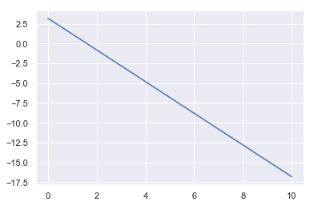

```python
X = np.linspace(0,10, 11).reshape((-1, 1))
T = -2 * X + 3.2

ls = LinearRegress()

ls.train(X, T)

plt.plot(ls.use(X))
```

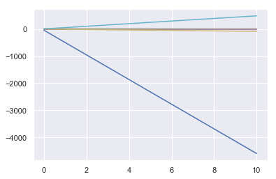

```python
lms = LMS(0.1)
for x, t in zip(X, T):
    lms.train_step(x, t)
    plt.plot(lms.use(X))
```

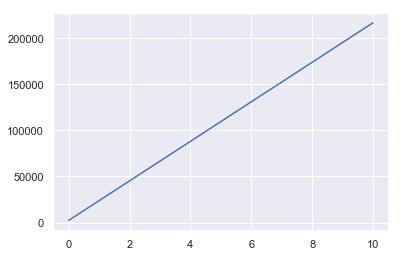

```python
lms.train(X, T)
plt.plot(lms.use(X))
```

# Preliminary Test

After finishing the implmentation of LinearRegress and LMS classes, run the following cell to test if your implementation is correct. Make sure and check your codes to pass all three tests as in sample outputs.

```python
##################### WHAT I WILL RELEASE ############

# Self-Test code for accuracy of your model - DO NOT MODIFY THIS
# Primilnary test data
X = np.array([[2,5],
              [6,2],
              [1,9],
              [4,5],
              [6,3],
              [7,4],
              [8,3]])
T = X[:,0, None] * 3 - 2 * X[:, 1, None] + 3
N = X.shape[0]

def rmse(T, Y):
    return np.sqrt(np.sum((T-Y)**2))

model_names = ['LS', 'LMS_All', 'LMS_1STEP']
models = [LinearRegress(), LMS(0.02), LMS(0.02)]
#train
for i, model in enumerate(models):
    print("training ", model_names[i], "...")
    if i == len(models) -1:
        # train only one step for LMS2
        model.train_step(X[0], T[0])
    else:
        model.train(X, T)

def check(a, b, eps=np.finfo(float).eps):
    if abs(a-b) > eps:
        print("failed.", a, b)
    else:
        print("passed.")

errors = [1.19e-13, 2.8753214702, 38.0584918251]
for i, model in enumerate(models):
    print("---- Testing ", model_names[i], "...", end=" ")

    # rmse test
    err = rmse(T, model.use(X))
    if check(err, errors[i], eps=1e-10):
        print ("check your weights: ", model.w)
        print ("oracle: ", )
```

```
training  LS ...
training  LMS_All ...
training  LMS_1STEP ...
---- Testing  LS ... passed.
---- Testing  LMS_All ... passed.
---- Testing  LMS_1STEP ... passed.
```

# Experiments

Apply LS and LMS methods on the data and discuss the results. Please describe your experiment and related codes. You may have subsections of results and discussions here.

### Description and codes

Let's create some functions which we will use repeatedly in code.

```python
def plot_ls(ytest,T):
    plt.figure(figsize=(10,5))
    plt.plot(ytest.values[0::10], label='Target Values', color='red')
    plt.plot(T[0::10], label='Predicted Values', color = 'blue')
    plt.xlabel('Data with 10 intervals', fontsize=14)
    plt.ylabel('Apparent Temperature', fontsize=14)
    plt.title('1. Least Square Model: RMSE value: '+ str(rmse(ytest.values,T)), fontsize=14)
    plt.legend()
    print()
```

```python
def plot(ytest,T):
    plt.figure(figsize=(10,5))
    plt.plot(ytest.values[0::10], label='Target Values', color='red')
    plt.plot(T[0::10], label='Predicted Values', color = 'blue')
    plt.xlabel('Data with 10 intervals', fontsize=14)
    plt.ylabel('Apparent Temperature', fontsize=14)
    plt.title('1. Least Mean Square Model: RMSE value: '+ str(rmse(ytest.values,T)), fontsize=14)
    plt.legend()
    print()
```

```python
def split_dataframe(df):
    Xtrain = df[['Humidity','Wind Speed (km/h)','Wind Bearing (degrees)','Visibility (km)']].head(8000)
    Xtest = df[['Humidity','Wind Speed (km/h)','Wind Bearing (degrees)','Visibility (km)']].tail(2000)
    ytrain = df['Apparent Temperature (C)'].head(8000)
    ytest = df['Apparent Temperature (C)'].tail(2000)
    return Xtrain,ytrain,Xtest,ytest
```

We will fist check our results on not-normalized data with some outliers in it.

### Visualization of the results

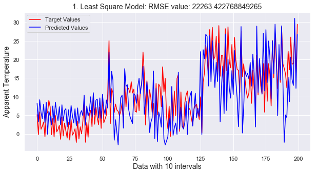

```python
Xtrain, ytrain,Xtest, ytest = split_dataframe(df_num)
ls = LinearRegress()
ls.train(Xtrain.values, ytrain.values.reshape(-1, 1))
T = ls.use(Xtest.values)
plot_ls(ytest,T)
```

```
IQR: Temperature (C)              14.150000
Apparent Temperature (C)     16.527778
Humidity                      0.290000
Wind Speed (km/h)             8.307600
Wind Bearing (degrees)      174.000000
Visibility (km)               6.472200
dtype: float64
```

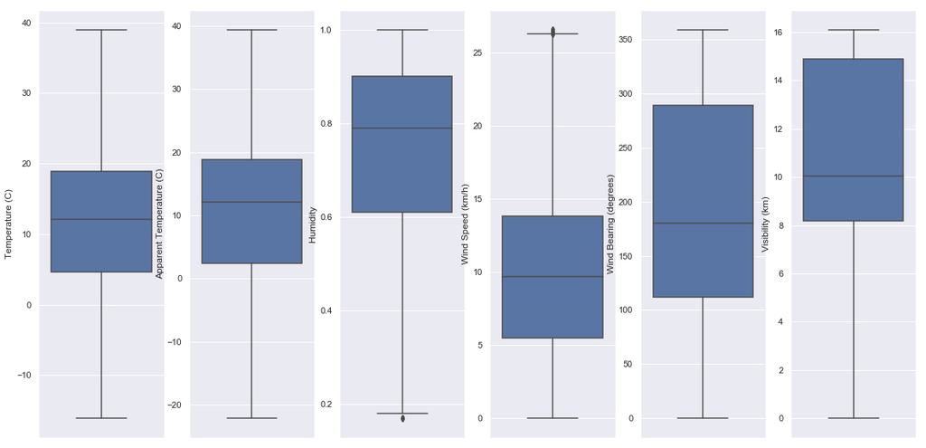

```python
Q1 = df_num.quantile(0.25)
Q3 = df_num.quantile(0.75)
IQR = Q3 - Q1
print('IQR:',IQR)
df_new1 = df_num[~((df_num < (Q1 - 1.5 * IQR)) |(df_num > (Q3 + 1.5 * IQR))).any(axis=1)]
fig, axes =plt.subplots(1,6,figsize=(20,10))
for i in range (0,df_new1.shape[1]):
    sns.boxplot(y=str(df_new1.columns.values[i]),data=df_new1,ax=axes[i%6])
```

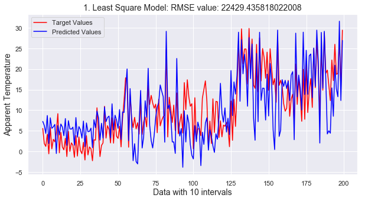

```python
Xtrain, ytrain,Xtest, ytest = split_dataframe(df_new1)
ls = LinearRegress()
ls.train(Xtrain.values, ytrain.values.reshape(-1, 1))
T = ls.use(Xtest.values)
plot_ls(ytest,T)
```

Removing outliers from the data did not help much. To improve it further we can normalizing the data , since RMSE score also seems high in above cases.

### Normalizing data

**Values for some variables are not commonly scaled which might affect our prediction. We can normalize this data using min max normalization method.**

```python
dataNorm = df_new1.sample(10000)
dataNorm=((dataNorm-dataNorm.min())/(dataNorm.max()-dataNorm.min()))
```

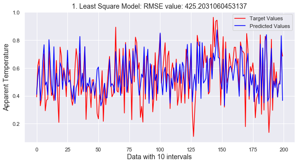

```python
Xtrain, ytrain,Xtest, ytest = split_dataframe(dataNorm)
ls = LinearRegress()
ls.train(Xtrain.values, ytrain.values.reshape(-1, 1))
T = ls.use(Xtest.values)
plot_ls(ytest,T)
```

### LMS Experiments

Now let's check LMS results. We will start with non-normalized data with ouliers present in it and see the results. We are try different learning rates ranginf from 0.01 to 0.00001

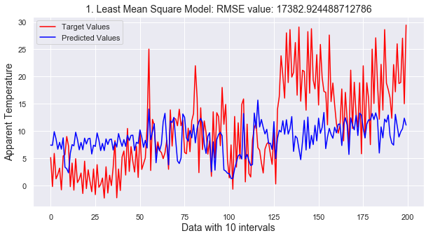

```python
Xtrain, ytrain,Xtest, ytest = split_dataframe(df_num)
alpha= [0.01,0.001,0.0001,0.00001]
for i in alpha:
    lms = LMS(i)
    lms.train(Xtrain.values, ytrain.values.reshape(-1, 1))
    T = lms.use(Xtest.values)
    fig = plt.figure(figsize=(10,5))
    plot(ytest,T)
```

[output not shown]

As learning rate is decreasing model seems to make improvments but Results are not at all good after reaching 0.00001 also, RMSE score is also very high. Let's test our results on normalized data after removing outliers now.

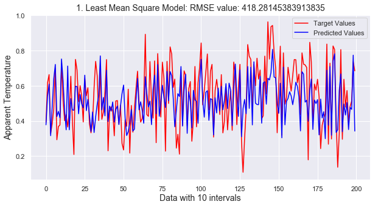

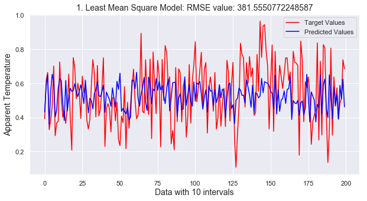

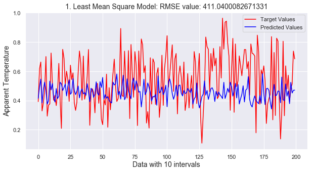

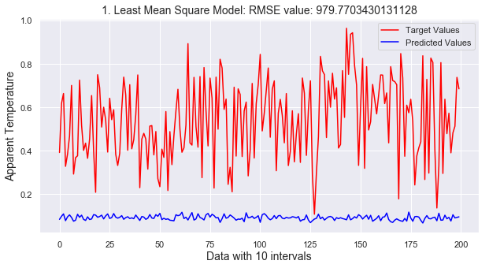

```python
Xtrain, ytrain,Xtest, ytest = split_dataframe(dataNorm)
alpha= [0.01,0.001,0.0001,0.00001]
for i in alpha:
    lms = LMS(i)
    lms.train(Xtrain.values, ytrain.values.reshape(-1, 1))
    T = lms.use(Xtest.values)
    fig = plt.figure(figsize=(10,5))
    plot(ytest,T)
```

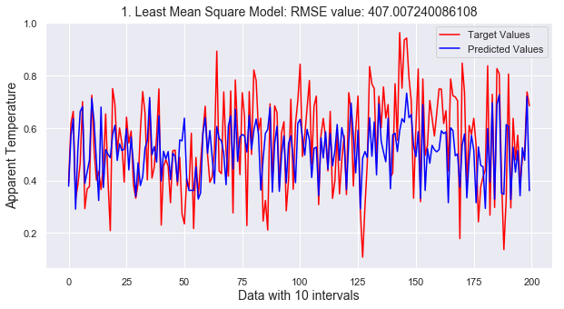

```python
Xtrain, ytrain,Xtest, ytest = split_dataframe(dataNorm)
lms = LMS(0.004)
lms.train(Xtrain.values, ytrain.values.reshape(-1, 1))
T = lms.use(Xtest.values)
fig = plt.figure(figsize=(10,5))
plot(ytest,T)
```

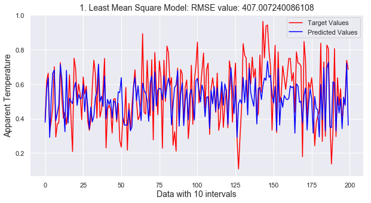

```python
Xtrain, ytrain,Xtest, ytest = split_dataframe(dataNorm)
lms = LMS(0.004)
lms.train(Xtrain.values, ytrain.values.reshape(-1, 1))[0]
T = lms.use(Xtest.values)
fig = plt.figure(figsize=(10,5))
plot(ytest,T)
```

## Analysis and comparison of algorithms

[output not shown]

# Conclusions

Discuss the challenges or somethat that you learned. If you have any suggestion about the assignment, you can write about it.

1. Learned what is linear regression and how predictions can be made using it.
2. An important challenge faced was how to plot multivariate independent variables and dependent variable for both testing and predicted data
3. We also learned how important preprocessing of the data is for goodness of model.
4. Learned more about numpy arrays , pandas dataframe and how linear algebra is helpful to make predictions.
5. We also learned how to remove outliers from the data and in what way it can affect our predictions.
6. Updating learning rate (alpha) even by slightly in LMS can affect model vastly.

# References

https://matplotlib.org/

https://pandas.pydata.org/

https://www.kaggle.com/budincsevity/szeged-weather

https://en.wikipedia.org/wiki/

http://docs.statwing.com/

# Extra Credit

If you want to work more for an extra credit, place your work here for additional analysis: weight and residual analysis. Try to answer to the following questions:

- what is the most and least significant features for your data.
- what are the consequences if you remove those features from the model? (Show your work!)
- produce residual plots and observe the patterns for the goodness of fit

**Note: the extra credit is an additional work that needs complete programming, experiments, analysis, and writing to get one.**

To check which features are significant and which not lets plot co-relation matrix.

```python
df_extra = pd.read_csv(r'weatherHistory.csv')
```

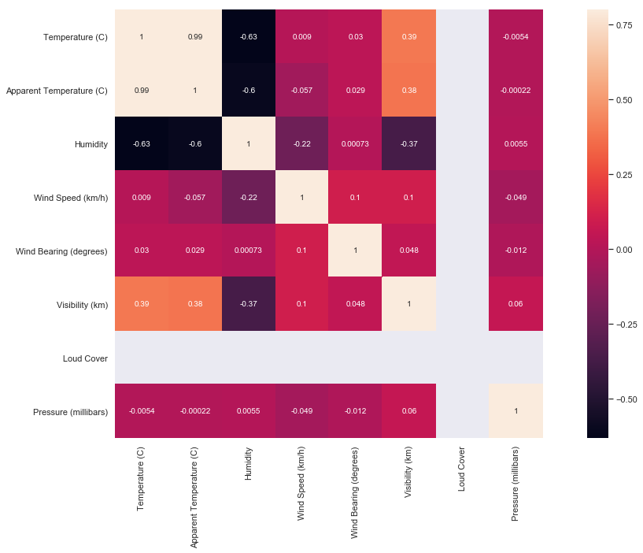

```python
corrmatr = df_extra[['Temperature (C)','Apparent Temperature (C)','Humidity','Wind Speed (km/h)','Wind Bearing (degrees)','Visibility (km)','Loud Cover','Pressure (millibars)']].corr()
fig,ax= plt.subplots()
fig.set_size_inches(20,10)
sns.heatmap(corrmatr,vmax=.8, square=True,annot=True)
```

- **Looking at the corelation matrix we can say that temperature and apparent temperature are strongly correlated.**
- **Also humidity and temperature or apparent temprature are inversely proportional.**
- **Features like wind bearing and loud cover are least significant features.**

Let's test these hypothesis by using Least square and Least Mean square method, Ideally if we don't consider less significant features LS and LMS shall give same results as we tested earlier, whereas if dont take most significant features into consideration prediction should not be as good as above. Also Visibility seems to be one of most significant feature, it could be possible when there is more rain or snow visibility is less and vice-versa , eventually affecting apparent tempreatre.

- Applying least square method without most significant features which are humidity and Temperature.

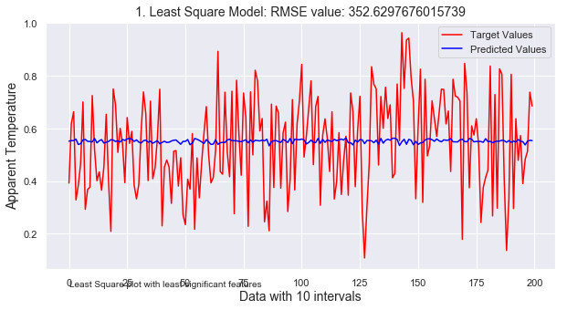

```python
Xtrain = dataNorm[['Wind Speed (km/h)','Wind Bearing (degrees)']].head(8000)
Xtest = dataNorm[['Wind Speed (km/h)','Wind Bearing (degrees)']].tail(2000)
ytrain = dataNorm['Apparent Temperature (C)'].head(8000)
ytest = dataNorm['Apparent Temperature (C)'].tail(2000)
ls = LinearRegress()
ls.train(Xtrain.values, ytrain.values.reshape(-1, 1))
T = ls.use(Xtest.values)
plot_ls(ytest,T)
plt.text(0,0,'Least Square plot with least significant features')
```

**It can be clearly seen that when we remove most signifincant features predictions are not at all good.**

**Let's check the same using LMS method.**

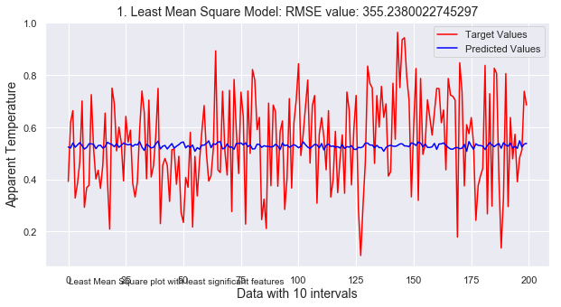

```python
Xtrain = dataNorm[['Wind Speed (km/h)','Wind Bearing (degrees)']].head(8000)
Xtest = dataNorm[['Wind Speed (km/h)','Wind Bearing (degrees)']].tail(2000)
ytrain = dataNorm['Apparent Temperature (C)'].head(8000)
ytest = dataNorm['Apparent Temperature (C)'].tail(2000)
lms = LMS(0.004)
lms.train(Xtrain.values, ytrain.values.reshape(-1, 1))
T = lms.use(Xtest.values)
plot(ytest,T)
plt.text(0,0,'Least Mean Square plot with least significant features')
```

**Even in above graph it is clear that LMS predictions are not good when most significant features are removed**

Now let's consider most significant features and avoid least significant features and see the reults

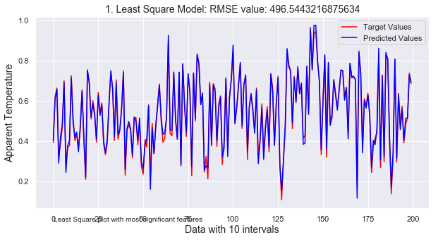

```python
Xtrain = dataNorm[['Temperature (C)','Humidity','Visibility (km)']].head(8000)
Xtest = dataNorm[['Temperature (C)','Humidity','Visibility (km)']].tail(2000)
ytrain = dataNorm['Apparent Temperature (C)'].head(8000)
ytest = dataNorm['Apparent Temperature (C)'].tail(2000)
ls = LinearRegress()
ls.train(Xtrain.values, ytrain.values.reshape(-1, 1))
T = ls.use(Xtest.values)
plot_ls(ytest,T)
plt.text(0,0,'Least Square plot with most significant features')
```

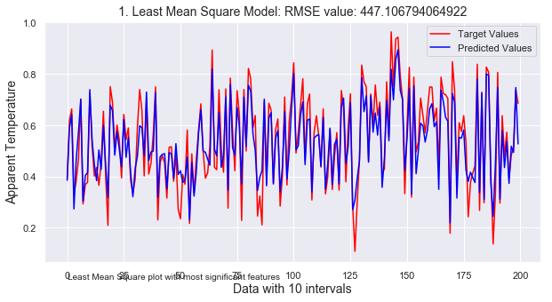

```python
Xtrain = dataNorm[['Temperature (C)','Humidity','Visibility (km)']].head(8000)
Xtest = dataNorm[['Temperature (C)','Humidity','Visibility (km)']].tail(2000)
ytrain = dataNorm['Apparent Temperature (C)'].head(8000)
ytest = dataNorm['Apparent Temperature (C)'].tail(2000)
lms = LMS(0.004)
lms.train(Xtrain.values, ytrain.values.reshape(-1, 1))
T = lms.use(Xtest.values)
plot(ytest,T)
plt.text(0,0,'Least Mean Square plot with most significant features')
```

### Goodness of the model

**In order to check the goodness of the model lets plot residual plots and scatter plots**.

We can see below that actual test data and predicted data is linearly distributed.

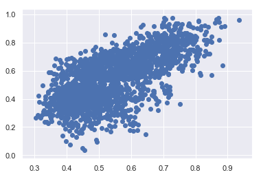

```python
Xtrain, ytrain,Xtest, ytest = split_dataframe(dataNorm)
ls = LinearRegress()
ls.train(Xtrain.values, ytrain.values.reshape(-1, 1))
T = ls.use(Xtest.values)
plt.scatter(T,ytest)
```

**Lets capture residuals from LS and LMS**.

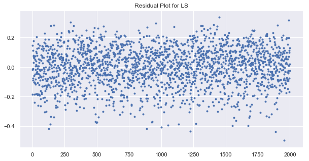

```python
## code for residual plots ##
Xtrain, ytrain,Xtest, ytest = split_dataframe(dataNorm)
ls = LinearRegress()
ls.train(Xtrain.values, ytrain.values.reshape(-1, 1))
T = ls.use(Xtest.values)
diff = ytest.values.reshape(-1, 1) - T
cnt = np.arange(len(T))
fig=plt.figure(figsize=(10, 5), facecolor='w')
plt.scatter(cnt,diff,marker='.')
plt.title("Residual Plot for LS")
```

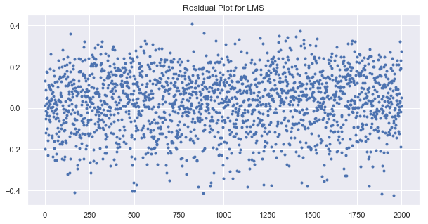

```python
## code for residual plots ##
Xtrain, ytrain,Xtest, ytest = split_dataframe(dataNorm)
lms = LMS(0.004)
lms.train(Xtrain.values, ytrain.values.reshape(-1, 1))
T = lms.use(Xtest.values)
diff = ytest.values.reshape(-1, 1) - T
cnt = np.arange(len(T))
fig=plt.figure(figsize=(10, 5), facecolor='w')
plt.scatter(cnt,diff,marker='.')
plt.title("Residual Plot for LMS")
```

### Observations:

- Residual plot shows that most of the residues are above 0 and good amount of residues are below 0.
- Randomness of residues also indicates goodness of fit for linear model.